# Bayesian lab

Ben Bolker

24 June 2023

Licensed under the [Creative Commons attribution-noncommercial license](http://creativecommons.org/licenses/by-nc/3.0/). Please share & remix noncommercially, mentioning its origin.

```r
library(MCMCglmm)
library(lme4)
library(brms)
library(coda)
library(lattice)
library(reshape2) ## for melt()
## devtools::install_github("mjskay/tidybayes")
## library(tidybayes) ## optional
library(ggplot2); theme_set(theme_bw())
library(bayesplot)
```

```r
load("../../data/starling.RData")   ## loads "dataf"
```

As a preliminary/context for the difficulties we will experience below, run a standard `lmer` model (`stmass~mnth*roostsitu+(1|subject)`) and plot the likelihood profile for the variance components. Neither of the MLEs is exactly at zero, but the lower 95% confidence interval of among-subject standard deviance definitely includes zero … (cutoff shown in red). Even the 50% CI includes zero (dashed line).

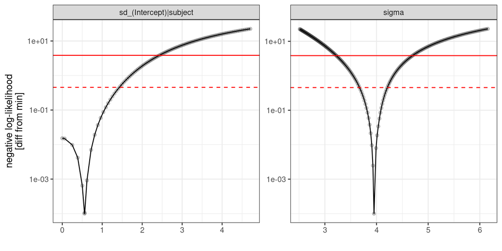

### Analyze starling data with `MCMCglmm`

`MCMCglmm` does a Bayesian analysis, which can be useful for more flexible inference, and has some more flexible covariance structures etc.. For basic models, the syntax is very similar to `lme4`/`nlme`. (The random effect is specified separately, as in `lme`.)

```r
mcmcglmm1 <- MCMCglmm(stmass~mnth*roostsitu,
                      random=~subject,
                      data=dataf,
                      verbose=FALSE)
```

We use `verbose=FALSE` to turn off the progress messages, which would be ugly in this document but are generally useful.

- Compare the results (use `summary()`: printing out the a raw `MCMCglmm` model is ugly).

For MCMC approaches, it is your responsibility to check that the chain(s) are well-behaved.

There is a `plot(.)` method for `MCMCglmm` objects - it shows the trace plots and density plots for all parameters - but it’s not very pretty or very flexible. I prefer `xyplot()` for trace plots and `densityplot()` for density plots; you have to load the `lattice` package first, and you have to extract the relevant component of the `MCMCglmm` object and convert it to an `mcmc` object.

```r
xyplot(
    as.mcmc(mcmcglmm1$Sol),  ## convert matrix to `mcmc` object
    layout=c(2,4)            ## customize panel arrangement
)
```

[output not shown]

You can plot the distributions:

```r
densityplot(mcmcglmm1$Sol)
```

[output not shown]

but I prefer *violin plots* for this case: first need to

```r
md <- reshape2::melt(as.matrix(mcmcglmm1$Sol)) ## change matrix to long form
```

```r
ggplot(subset(md,Var2!="(Intercept)"),
       aes(Var2,value))+geom_violin(fill="grey")+
    geom_hline(yintercept=0,lty=2)+
    coord_flip()
```

[output not shown]

**But**: the variance components are definitely problematic.

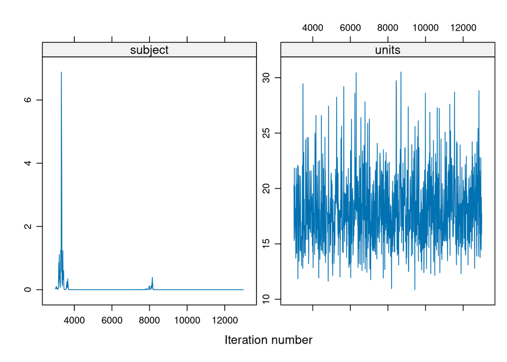

```r
xyplot(
    as.mcmc(mcmcglmm1$VCV),  ## convert matrix to `mcmc` object
    layout=c(2,1)            ## customize panel arrangement
)
```

Let’s try the simplest brute-force approach, running the model for longer by increasing the `nitt` parameter from its default of 13,000:

```r
mcmcglmm1L <- MCMCglmm(stmass~mnth*roostsitu,
                      random=~subject,
                      data=dataf,
                      nitt=2e5,
                      verbose=FALSE)
```

Still bad:

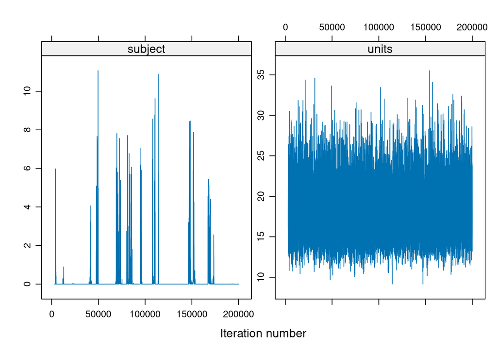

```r
xyplot(
    as.mcmc(mcmcglmm1L$VCV),  ## convert matrix to `mcmc` object
    layout=c(2,1)            ## customize panel arrangement
)
```

We probably have to change the prior, specifically choosing a prior that doesn’t have a big spike at zero. The prior is a *triple* list;

```r
mcmcglmm2 <- MCMCglmm(stmass~mnth*roostsitu,
                      random=~subject,
                      data=dataf,
                      prior=list(G=list(list(V=1,nu=5))),
                      verbose=FALSE)
```

This works to give us a well-behaved trace plot:

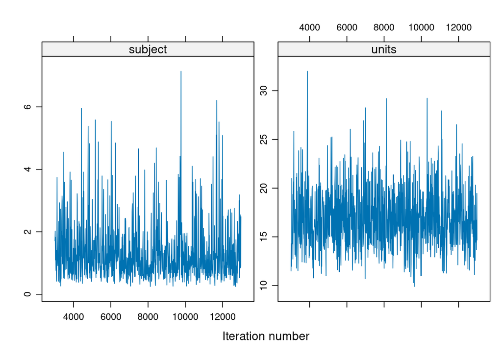

```r
xyplot(
    as.mcmc(mcmcglmm2$VCV),  ## convert matrix to `mcmc` object
    layout=c(2,1)            ## customize panel arrangement
)
```

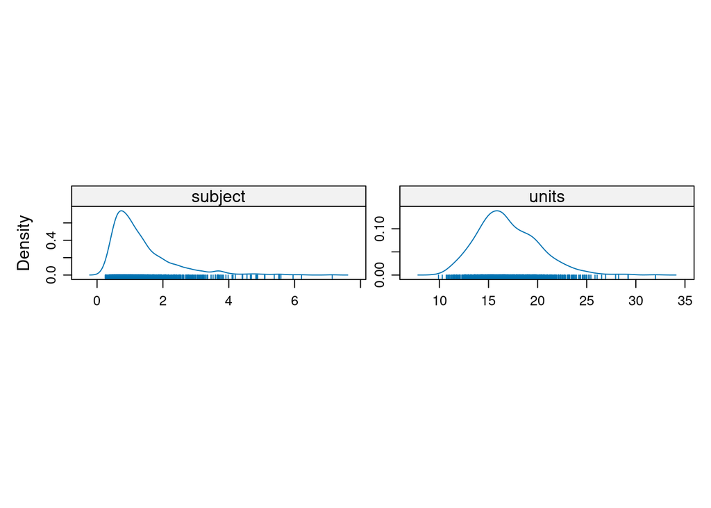

```r
densityplot(
    as.mcmc(mcmcglmm2$VCV),  ## convert matrix to `mcmc` object
    layout=c(2,1)            ## customize panel arrangement
)
```

## parameter-expanded priors:

The pathologies of the mathematically convenient conjugate (inverse-gamma/inverse-Wishart) priors can be overcome in `MCMCglmm` by changing to what are called *parameter-expanded priors* (see Section 8.0.2 in the “CourseNotes” vignette of the `MCMCglmm` package: `vignette("CourseNotes",package="MCMCglmm")` or [here](https://cran.r-project.org/web/packages/MCMCglmm/vignettes/CourseNotes.pdf). This is mathematically a bit complicated, but practically it boils down to specifying four parameters (`V`, `nu`, `alpha.mu`, and `alpha.V`) instead of two. The good news is that you can generally set `V=1` and `alpha.mu=0`, which leaves only two to choose from. `alpha.V` gives the expected variance (so `sqrt(alpha.V)` is the expected standard deviation), and `nu` is now equivalent to the degrees of freedom for a $t$-distribution. Setting `V=1, nu=nu, alpha.mu = 0, alpha.V=s^2` gives a half-$t$ distribution with standard deviation `s` and df `nu`, e.g. for `nu=1`, `s=25`:

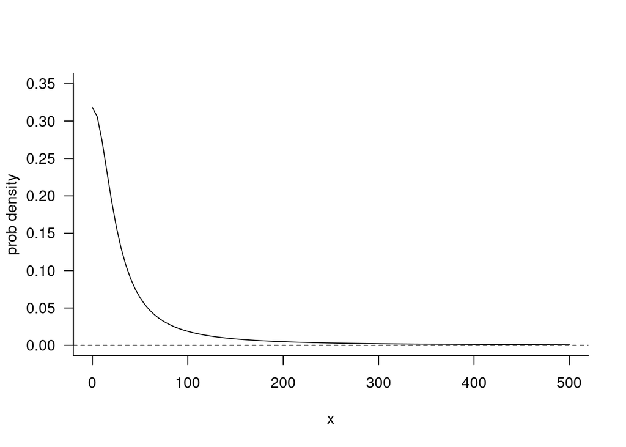

```r
par(las=1,bty="l")
curve(dt(x/25,df=1),from=0,to=500,ylim=c(0,0.35),
      ylab="prob density")
abline(h=0,lty=2)
```

Set up the prior:

```r
prior2 <- list(G = list(G1 = list(V = 1, nu = 1,
                                  alpha.mu = 0, alpha.V = 25^2)))
```

Run the model:

```r
mcmcglmm3 <- MCMCglmm(stmass~mnth*roostsitu,
                      random=~subject,
                      data=dataf,
                      prior=prior2,
                      verbose=FALSE)
```

Looks good, and looks less shifted away from zero:

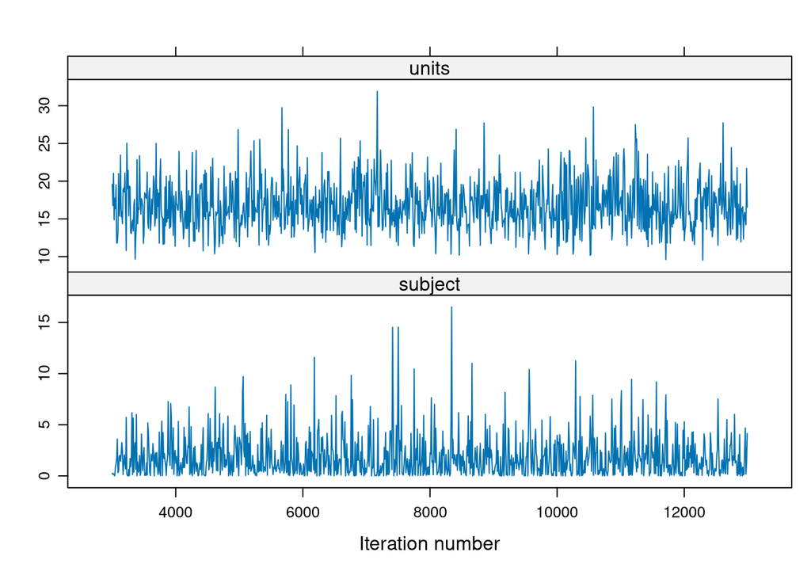

```r
mm <- as.mcmc(mcmcglmm3$VCV)
xyplot(mm)
```

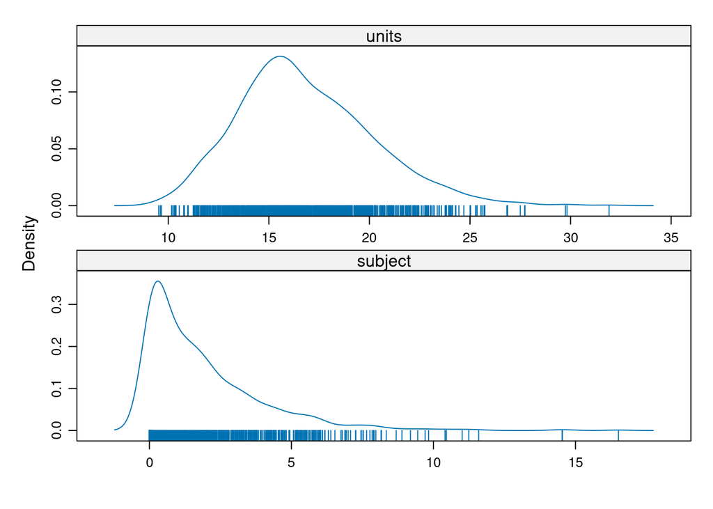

```r
densityplot(mm)
```

## with brms

```r
brms1 <- brm(stmass~mnth*roostsitu+(1|subject),
             family=gaussian,
             data=dataf)
saveRDS(brms1,file="brms1.rds")
```

```r
brms1 <- readRDS("brms1.rds")
print(brms1)
plot(brms1)
library(shinystan)
launch_shinystan(as.shinystan(brms1$fit))
```

Diagnostics with `bayesplot` or `shinystan` packages …

## with tmbstan

The `tmbstan` package allows us to use Hamiltonian MC on a fitted `glmmTMB` model (but not to set priors … yet …)

```r
library(glmmTMB)
library(tmbstan)
glmmTMB1 <- glmmTMB(stmass~mnth*roostsitu+(1|subject),data=dataf,
                    REML=FALSE)
glmmTMB_mcmc <- tmbstan(glmmTMB1$obj)
broom.mixed::tidy(glmmTMB_mcmc)
```

## Histograms vs densities of posterior distributions

One drawback of density plots is that they don’t work very precisely near boundaries, so it can be hard to see whether the mode of the prior distribution is at zero or not. (This isn’t *terribly* important in a practical sense, but I was curious whether the various priors we set actually shifted the posterior mode away from zero or not.) Histograms can help in this case:

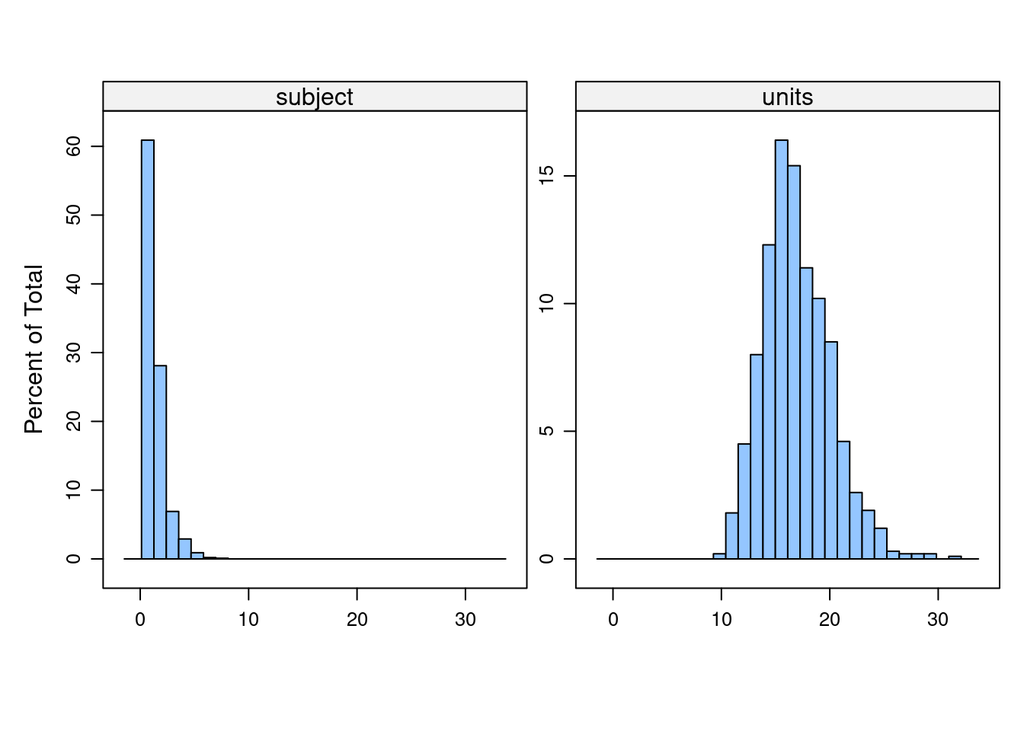

```r
source("../../R/histogram.mcmc.R")
histogram(
    as.mcmc(mcmcglmm2$VCV),  ## convert matrix to `mcmc` object
    layout=c(2,1),           ## customize panel arrangement
    nint=30
)
```

or with `ggplot`:

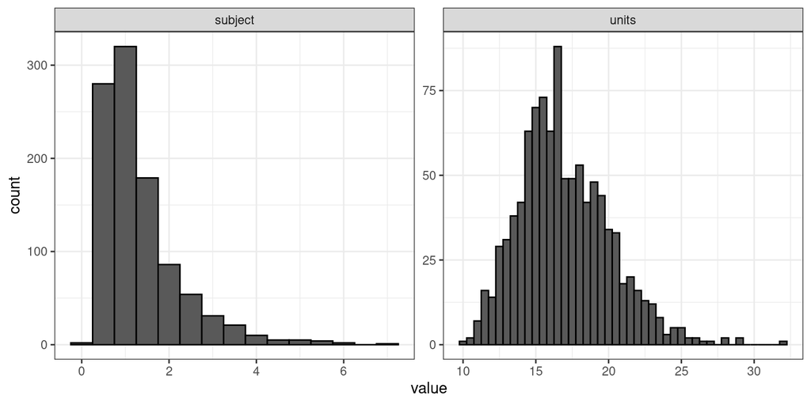

```r
mmr <- reshape2::melt(as.matrix(mcmcglmm2$VCV))
ggplot(mmr,aes(value))+
    geom_histogram(binwidth=0.5,colour="black")+
    facet_wrap(~Var2,scale="free")
```